# Practical Machine Learning

Chris K

October 13, 2015

## Executive Summary

This paper demostrates highly accurate recognition of human motion thru the application of machine learning techniques. It will be shown that accurate feedback can be provided.

## Introduction

In 2013 “Qualitative Activity Recognition of Weight Lifting Exercises” http://groupware.les.inf.puc-rio.br/public/papers/2013.Velloso.QAR-WLE.pdf was published. Our thanks to them for publishing this data. It notes that traditionally research into activity recognition has focused on determining what activity is happening. Many fitness tracker (i.e. FitBit) use this in trying to determine activity levels. The authors wish to add to this the determination of how well an activity is done, the quality of the activity. This is valuable since proper exercise technique is key to preventing injury as well as maximizing exercise benefit.

Briefly (see the paper for details) several test subjects performed repetitions of an bicep curl. They performed the activity both correctly and incorrectly using common mistakes. The motions were captured by sensors that tracked body movements and then classified by machine learning into different classes. Each class represent if the activity was done properly or improperly and what the type of mistake was.

## Goal

The purpose of THIS paper is to replicate the original paper’s result. Machine learning techniques will be applied to the original motion data in an attempt to identify when proper and improper techniques are happening.

## Data Description

Body motion was capture from four devices, one attached to the arm (upper arm), forearm, belt and dumbbell. Each provided 9 degrees of motion capture - x,y,z of acceleration, gyroscope and magnetometer (compass). No explicit data dictionary was given, however the paper describes how the data was collected and how additional features were calculated at a high level. Combined with the names of the columns, this enabled exploratory data analysis to commence.

The data set consists of 19622 observations of 160 variables. The variables can be described as five groups. The first group represents common data applicable across all sensors, such as the user name, and the classification of the activity. Besides the classfication of the activity, these will not be considered further. Note that timestamps of the readings is available, and may be reconsidered if unsatisfactory results are obtained.  
Each of the remaining four groups represent one of the four sensors. Exploratory data analysis show many of these variables are either blank, NA or in a few places indicate a division by zero error. Note that a common variable “new_window” correlated with the observations that did not have these issues. It appears these variables are an artifact from the sliding window analysis the authors speak of in their paper. Due to the lack of data, these variables will not be considered further, unless unsatsfactory results are obtained or time permits further analysis.

Final step is to remove predictors that show little useful variance and those predictors that are highly correlated to one another.

## Preprocessing Features

Load required libraries

```r
suppressWarnings(library(caret))
suppressWarnings(require(randomForest))
suppressWarnings(require(rpart))
suppressWarnings(require(gbm))
suppressWarnings(require(plyr))
```

Exploratory data analysis was perform, and those variables related to the sensors will be highlighted for study. EDA showed many variables with missing data, and these will be ignored.

```r
dat <- read.csv("Data/pml-training.csv",stringsAsFactors = TRUE)
n <- names(dat)
allSensors <- grepl("_dumbbell",n) | grepl("_arm",n) |grepl("_belt",n) |grepl("_forearm",n)
outcome <- grepl("classe",n)
na19216 <- data.frame(flag = apply(dat,2,function(x) { sum(is.na(x)) == 19216 }))$flag
blank19216 <- data.frame(flag = apply(dat,2,function(x) { sum(x == "") == 19216 }))$flag
blank19216[is.na(blank19216)] <- FALSE
dat <- dat[outcome | (allSensors & !na19216 & !blank19216)]
```

Checking for variables that have a low variance and therefore would not bring value to the analysis. Note none were found after the manual data clean up above, but on the original data several were found.

```r
nearZero <- nearZeroVar(dat)
if( length( nearZero > 0) )  dat <- dat[-nearZero]
```

Shown is one example of two variables found to be highly correlated and therefore being redundant, will have one or the other removed. Several were found.

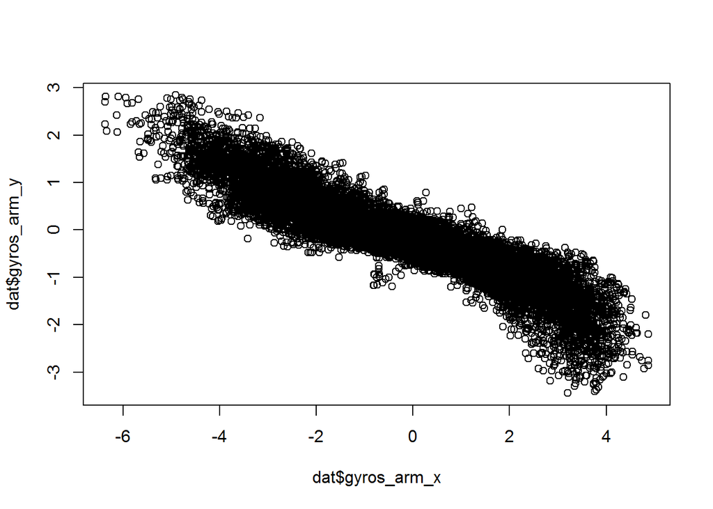

```r
plot(dat$gyros_arm_x,dat$gyros_arm_y)
```

```r
outcome <- grep("classe",names(dat))
M <- abs(cor(dat[,-outcome]));diag(M) <- 0
corVars <- findCorrelation(M)
m <- which(M > 0.9,arr.ind=T)
if( length( corVars > 0) )  dat <- dat[-corVars]
```

## Model Selection

The problem is one of classfication, and therefore several machine learning classfication algorthms will be tested. For the purpose of debugging R code, a tiny sliver of the available data was used. Model selection was based on the full data set.

```r
Debugging <- FALSE
if(Debugging){
    inSmall <- createDataPartition(dat$classe, p = 0.01, list = FALSE)
    tidySet <- dat[inSmall,]
} else {
    tidySet <- dat
}
```

The available data was partition into two data sets, one for training the model, one for final model evaluation.

```r
Publication <- TRUE
intrain <- createDataPartition(tidySet$classe, p = 0.6, list = FALSE)
trainSet <- tidySet[intrain,]
testSet <- tidySet[-intrain,]
```

Each model was run on the same training set. Results cached, due to the time needed to run. For publication the cached results were used, in case the paper needed editing. In order to avoid overfitting, we run the models with five fold cross validation. This will also allow a better out of sample error estimation.

```r
if(Publication){ #model was precomputed and stored
    fitRPART <- readRDS("fitRPART.rds")
    fitRF <- readRDS("fitRF.rds")
    fitGBM <- readRDS("fitGBM.rds")
    testSet <- read.csv("cachedtestSet.csv")
}else {
    write.csv(testSet,"cachedtestSet.csv")

    #trControl <- trainControl(method="repeatedcv", number=5, repeats = 5)
    trControl <- trainControl(method="cv", number=5)

    print("RPART"); start <- Sys.time()
    set.seed(123)
    fitRPART <- train(classe ~ ., data = trainSet, method = "rpart", trControl = trControl)
    saveRDS(fitRPART, "fitRPART.rds")

    end <- Sys.time();  print(end-start); print("FIT"); start <- Sys.time()
    set.seed(123)
    fitRF <- train(classe ~ ., data = trainSet, method = "rf", trControl = trControl, prox=TRUE)
    saveRDS(fitRF, "fitRF.rds")

    end <- Sys.time();  print(end-start); print("GBM"); start <- Sys.time()
    set.seed(123)
    fitGBM <- train(classe ~ ., data = trainSet, method = "gbm", trControl = trControl, verbose=FALSE)
    saveRDS(fitGBM, "fitGBM.rds")
    end <- Sys.time();  print(end-start)
}
```

Random Forest has the lowest estimated out of sample error rate. Reminder that the model was run with cross validation.

```r
r<-cbind( round(1-max(fitRF$results$Accuracy),4),
          round(1-max(fitGBM$results$Accuracy),4),
          round(1-max(fitRPART$results$Accuracy),4)  )
colnames(r)<-c("  Random Forest","  Gradient Boosting", "  Recursive Partitioning")
r
```

```
##        Random Forest   Gradient Boosting   Recursive Partitioning
## [1,]          0.0096              0.0436                   0.4542
```

## Model Evaluation

Now each model will be evaluated against the test data that was held out above, by running predictions.

```r
outcome <- grep("classe",names(testSet))
predRPART <- predict(fitRPART, testSet[-outcome])
predRF <- predict(fitRF, testSet[-outcome])
predGBM <- predict(fitGBM, testSet[-outcome])
r<-cbind( round(postResample(predRF,testSet$classe)[1],4),
          round(postResample(predGBM,testSet$classe)[1],4),
          round(postResample(predRPART,testSet$classe)[1],4)  )
colnames(r)<-c("  Random Forest","  Gradient Boosting", "  Recursive Partitioning")
r
```

```
##            Random Forest   Gradient Boosting   Recursive Partitioning
## Accuracy          0.9962              0.9695                   0.5712
```

Based on accuracy, which is how well the model predicts the correct outcome, Random Forest is best, edging out Generalized Boosted Regression. Recursive partitioning does not fare well compared to the other algorthms. We’ll explore in further detail the first two.

Sensitivity is how well the model performs in distinguishing true vs false positives. Looking at each class (reminder the data categorizes multiple incorrect activities as well as the correct one) to verify no weak point. The higher performing model matches favorably to the alternative.

```r
senRF  <- confusionMatrix(testSet$classe,predRF)$byClass[,"Sensitivity"]
senGBM <- confusionMatrix(testSet$classe,predGBM)$byClass[,"Sensitivity"]
r<- data.frame(Random_Forest = senRF,
               Stochastic_Gradient_Boosting = senGBM,
               Random_Forest_Higher = factor(senRF>senGBM))
r
```

```
##          Random_Forest Stochastic_Gradient_Boosting Random_Forest_Higher
## Class: A     0.9964254                    0.9857015                 TRUE
## Class: B     0.9973545                    0.9528178                 TRUE
## Class: C     0.9927061                    0.9417266                 TRUE
## Class: D     0.9945610                    0.9641745                 TRUE
## Class: E     0.9993046                    0.9943182                 TRUE
```

Specificity is how well the model performs in distinguishing true vs false negatives. Again, looking at each class. The higher performing model matches favorably to the alternative.

```r
senRF  <- confusionMatrix(testSet$classe,predRF)$byClass[,"Specificity"]
senGBM <- confusionMatrix(testSet$classe,predGBM)$byClass[,"Specificity"]
r<- data.frame(Random_Forest = senRF, Stochastic_Gradient_Boosting = senGBM, Random_Forest_Higher = factor(senRF>senGBM))
r
```

```
##          Random_Forest Stochastic_Gradient_Boosting Random_Forest_Higher
## Class: A     0.9996434                    0.9953638                 TRUE
## Class: B     0.9984212                    0.9898734                 TRUE
## Class: C     0.9989189                    0.9908612                 TRUE
## Class: D     0.9990852                    0.9926852                 TRUE
## Class: E     0.9992197                    0.9934762                 TRUE
```

Based on these results the Random Forest model is selected as the go forward model.

# Final prediction

Here a prediction using the above Random Forest model is made on new data that was not used to either train the model nor evaluate the performance. These predictions are then submitted to Coursera for scoring.

```r
set.seed(123)
validationSet <- read.csv("Data/pml-testing.csv",stringsAsFactors = TRUE)
answers <- as.character(predict(fitRF,validationSet))
#print(answers)

pml_write_files = function(x){
  n = length(x)
  for(i in 1:n){
    filename = paste0("answers/problem_id_",i,".txt")
    write.table(x[i],file=filename,quote=FALSE,row.names=FALSE,col.names=FALSE)
  }
}
pml_write_files(answers)
```

Final edit: Predictions on the Coursera set was 100% correct.

## Recursive Partitioning

```r
fitRPART
```

```
## CART
##
## 11776 samples
##    45 predictor
##     5 classes: 'A', 'B', 'C', 'D', 'E'
##
## No pre-processing
## Resampling: Cross-Validated (5 fold)
## Summary of sample sizes: 9422, 9421, 9420, 9421, 9420
## Resampling results across tuning parameters:
##
##   cp          Accuracy   Kappa      Accuracy SD  Kappa SD
##   0.02728999  0.5457660  0.4237382  0.03167462   0.04702614
##   0.03013764  0.5326062  0.4093745  0.01996470   0.03590717
##   0.04241813  0.4707161  0.3102684  0.10963602   0.18173863
##
## Accuracy was used to select the optimal model using  the largest value.
## The final value used for the model was cp = 0.02728999.
```

```r
confusionMatrix(testSet$classe,predRPART)
```

```
## Confusion Matrix and Statistics
##
##           Reference
## Prediction    A    B    C    D    E
##          A 1614   19  439  160    0
##          B  503  615  276  122    2
##          C  168   35 1124   41    0
##          D  173   53  316  649   95
##          E  229  180  393  160  480
##
## Overall Statistics
##
##                Accuracy : 0.5712
##                  95% CI : (0.5602, 0.5822)
##     No Information Rate : 0.3425
##     P-Value [Acc > NIR] : < 2.2e-16
##
##                   Kappa : 0.4549
##  Mcnemar's Test P-Value : < 2.2e-16
##
## Statistics by Class:
##
##                      Class: A Class: B Class: C Class: D Class: E
## Sensitivity            0.6007  0.68182   0.4411  0.57332  0.83189
## Specificity            0.8802  0.86996   0.9539  0.90512  0.86766
## Pos Pred Value         0.7231  0.40514   0.8216  0.50467  0.33287
## Neg Pred Value         0.8089  0.95465   0.7802  0.92637  0.98485
## Prevalence             0.3425  0.11496   0.3248  0.14428  0.07354
## Detection Rate         0.2057  0.07838   0.1433  0.08272  0.06118
## Detection Prevalence   0.2845  0.19347   0.1744  0.16391  0.18379
## Balanced Accuracy      0.7404  0.77589   0.6975  0.73922  0.84977
```

## Random Forest

```r
fitRF
```

```
## Random Forest
##
## 11776 samples
##    45 predictor
##     5 classes: 'A', 'B', 'C', 'D', 'E'
##
## No pre-processing
## Resampling: Cross-Validated (5 fold)
## Summary of sample sizes: 9420, 9421, 9420, 9422, 9421
## Resampling results across tuning parameters:
##
##   mtry  Accuracy   Kappa      Accuracy SD  Kappa SD
##    2    0.9883656  0.9852817  0.002262753  0.002861964
##   23    0.9904037  0.9878611  0.002221910  0.002811123
##   45    0.9847993  0.9807722  0.002354675  0.002979873
##
## Accuracy was used to select the optimal model using  the largest value.
## The final value used for the model was mtry = 23.
```

```r
confusionMatrix(testSet$classe,predRF)
```

```
## Confusion Matrix and Statistics
##
##           Reference
## Prediction    A    B    C    D    E
##          A 2230    2    0    0    0
##          B    8 1508    2    0    0
##          C    0    2 1361    5    0
##          D    0    0    5 1280    1
##          E    0    0    3    2 1437
##
## Overall Statistics
##
##                Accuracy : 0.9962
##                  95% CI : (0.9945, 0.9974)
##     No Information Rate : 0.2852
##     P-Value [Acc > NIR] : < 2.2e-16
##
##                   Kappa : 0.9952
##  Mcnemar's Test P-Value : NA
##
## Statistics by Class:
##
##                      Class: A Class: B Class: C Class: D Class: E
## Sensitivity            0.9964   0.9974   0.9927   0.9946   0.9993
## Specificity            0.9996   0.9984   0.9989   0.9991   0.9992
## Pos Pred Value         0.9991   0.9934   0.9949   0.9953   0.9965
## Neg Pred Value         0.9986   0.9994   0.9985   0.9989   0.9998
## Prevalence             0.2852   0.1927   0.1747   0.1640   0.1833
## Detection Rate         0.2842   0.1922   0.1735   0.1631   0.1832
## Detection Prevalence   0.2845   0.1935   0.1744   0.1639   0.1838
## Balanced Accuracy      0.9980   0.9979   0.9958   0.9968   0.9993
```

## Gradient Boosting

```r
fitGBM
```

```
## Stochastic Gradient Boosting
##
## 11776 samples
##    45 predictor
##     5 classes: 'A', 'B', 'C', 'D', 'E'
##
## No pre-processing
## Resampling: Cross-Validated (5 fold)
## Summary of sample sizes: 9421, 9420, 9421, 9421, 9421
## Resampling results across tuning parameters:
##
##   interaction.depth  n.trees  Accuracy   Kappa      Accuracy SD
##   1                   50      0.7379420  0.6679753  0.009702914
##   1                  100      0.8085938  0.7577444  0.005529834
##   1                  150      0.8417130  0.7996762  0.008786984
##   2                   50      0.8460428  0.8049429  0.003865071
##   2                  100      0.9028536  0.8770546  0.003781091
##   2                  150      0.9271400  0.9077897  0.003658032
##   3                   50      0.8914742  0.8625982  0.004498377
##   3                  100      0.9402174  0.9243315  0.002869451
##   3                  150      0.9564367  0.9448800  0.002596700
##   Kappa SD
##   0.012482346
##   0.006976633
##   0.011010731
##   0.004946571
##   0.004805446
##   0.004662433
##   0.005753062
##   0.003669836
##   0.003299160
##
## Tuning parameter 'shrinkage' was held constant at a value of 0.1
##
## Tuning parameter 'n.minobsinnode' was held constant at a value of 10
## Accuracy was used to select the optimal model using  the largest value.
## The final values used for the model were n.trees = 150,
##  interaction.depth = 3, shrinkage = 0.1 and n.minobsinnode = 10.
```

```r
confusionMatrix(testSet$classe,predGBM)
```

```
## Confusion Matrix and Statistics
##
##           Reference
## Prediction    A    B    C    D    E
##          A 2206   18    2    5    1
##          B   29 1454   31    4    0
##          C    0   38 1309   20    1
##          D    1    3   38 1238    6
##          E    2   13   10   17 1400
##
## Overall Statistics
##
##                Accuracy : 0.9695
##                  95% CI : (0.9655, 0.9732)
##     No Information Rate : 0.2852
##     P-Value [Acc > NIR] : < 2.2e-16
##
##                   Kappa : 0.9615
##  Mcnemar's Test P-Value : 1.962e-05
##
## Statistics by Class:
##
##                      Class: A Class: B Class: C Class: D Class: E
## Sensitivity            0.9857   0.9528   0.9417   0.9642   0.9943
## Specificity            0.9954   0.9899   0.9909   0.9927   0.9935
## Pos Pred Value         0.9884   0.9578   0.9569   0.9627   0.9709
## Neg Pred Value         0.9943   0.9886   0.9875   0.9930   0.9988
## Prevalence             0.2852   0.1945   0.1772   0.1637   0.1795
## Detection Rate         0.2812   0.1853   0.1668   0.1578   0.1784
## Detection Prevalence   0.2845   0.1935   0.1744   0.1639   0.1838
## Balanced Accuracy      0.9905   0.9713   0.9663   0.9784   0.9939
```